# Final presentation

2022-05-09

## Gene expression and flight performance analysis for different monarch populations

Analysis of two monarch populations, East and West:

- Differences in flight performance
- Correlation in the genetic profiles to check for distinction in the two populations

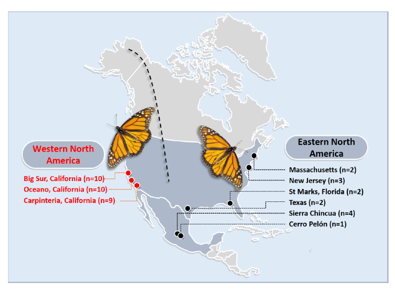

Fig.1-Map showing sampling locations

## Flowchart

[interactive chart not shown]

## Dataset

This is the final joined dataset we used for our analysis

```
## # A tibble: 6 × 21
##   ID    Gene_379 Gene_203 Gene_C2 Gene_C4 Gene_C5 Gene_C7 Sex   Population
##   <chr>    <dbl>    <dbl>   <dbl>   <dbl>   <dbl>   <dbl> <chr> <chr>
## 1 FL35     -5.74    -5.53   -4.80   -4.46   -4.42   -4.77 F     east
## 2 FL72     -6.21    -6.37   -4.73   -4.46   -4.46   -5.02 F     east
## 3 FL74     -4.86    -4.59   -2.65   -2.61   -2.90   -2.84 F     east
## 4 FL75     -6.14    -6.31   -4.84   -4.34   -4.44   -4.87 F     east
## 5 FL79     -4.40    -4.18   -3.01   -2.77   -3.18   -2.98 F     east
## 6 FL05     -6.00    -6.18   -4.94   -4.79   -4.25   -4.71 M     east
## # … with 12 more variables: premass <dbl>, postmass <dbl>, weightloss <dbl>,
## #   time.sec <dbl>, time.min <dbl>, distance <dbl>, averagevelocity <dbl>,
## #   maxvelocity <dbl>, power <dbl>, Area <dbl>, PC1_wing_size <dbl>,
## #   PC2_wing_shape <dbl>
```

## Results : Data exploring

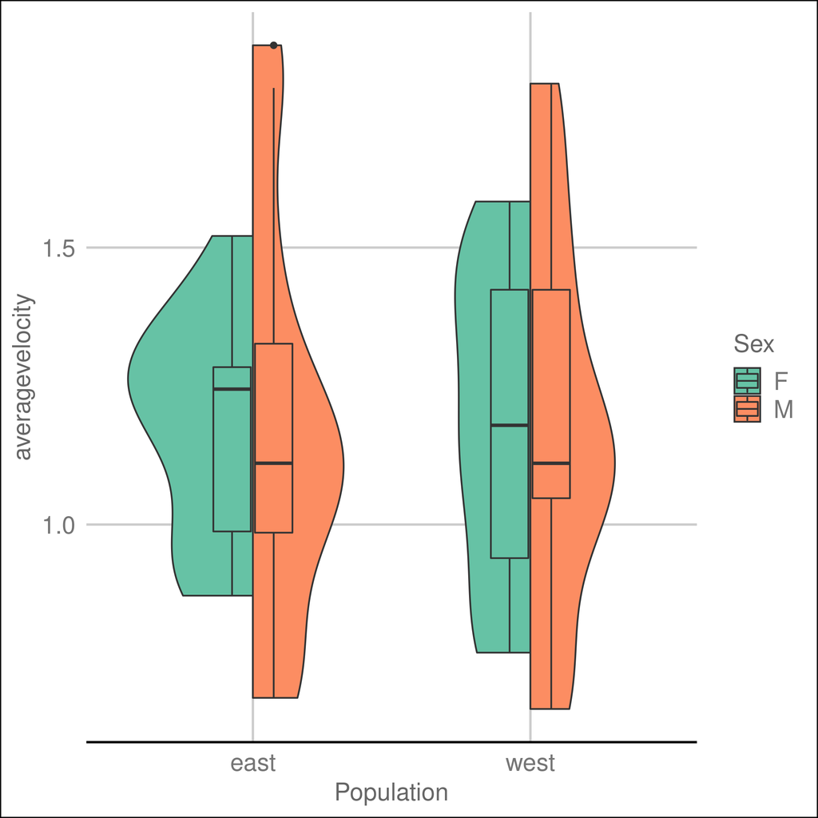

Fig.2-Violin plot of average velocity

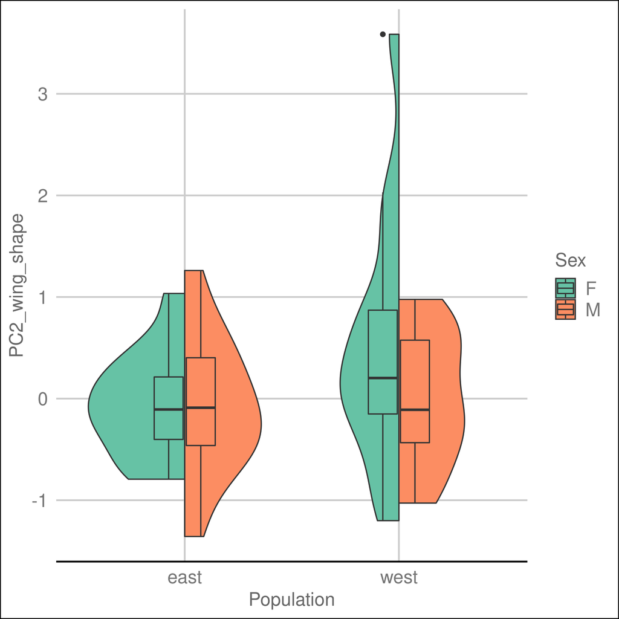

Fig.3-Violin plot of wing shape

```r
plots = map(numeric_ones,
            ~datadistribution_plot("Population",
                                   .,
                                   my_data_clean))
```

## Results : Data visualization

We performed T-test on flight performance variables and observed the following:

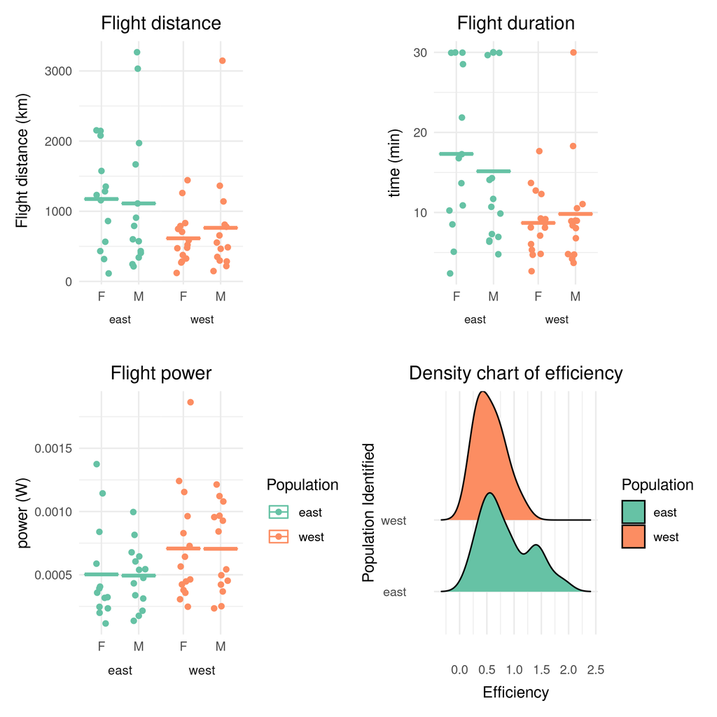

Fig.4-Analysis of flight performance

## Results : Data visualization

- **Genes 203 and 379** are heavily **downregulated** in both populations
- **Genes C2, C4, C5 and C7** seem to be comparatively more **downregulated** in Eastern Monarchs

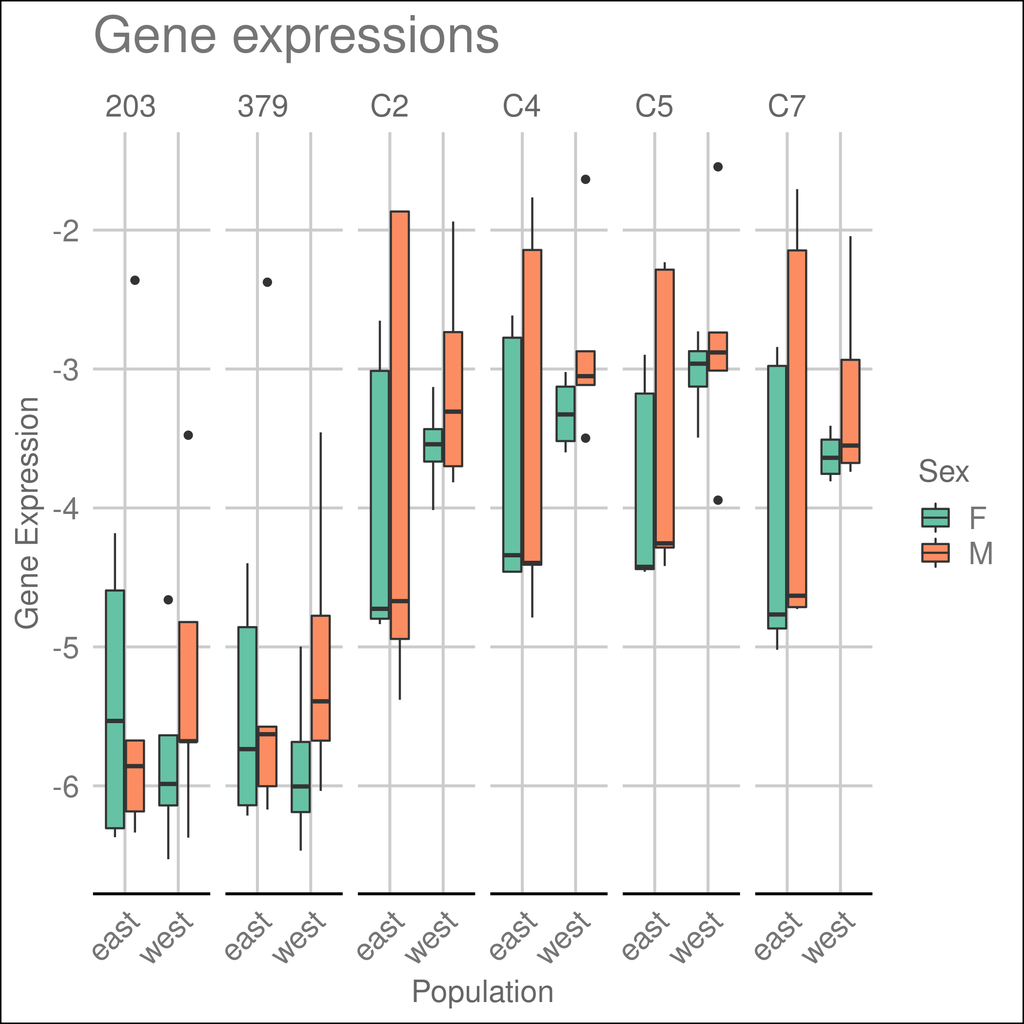

Fig.5-Box plots of gene expression

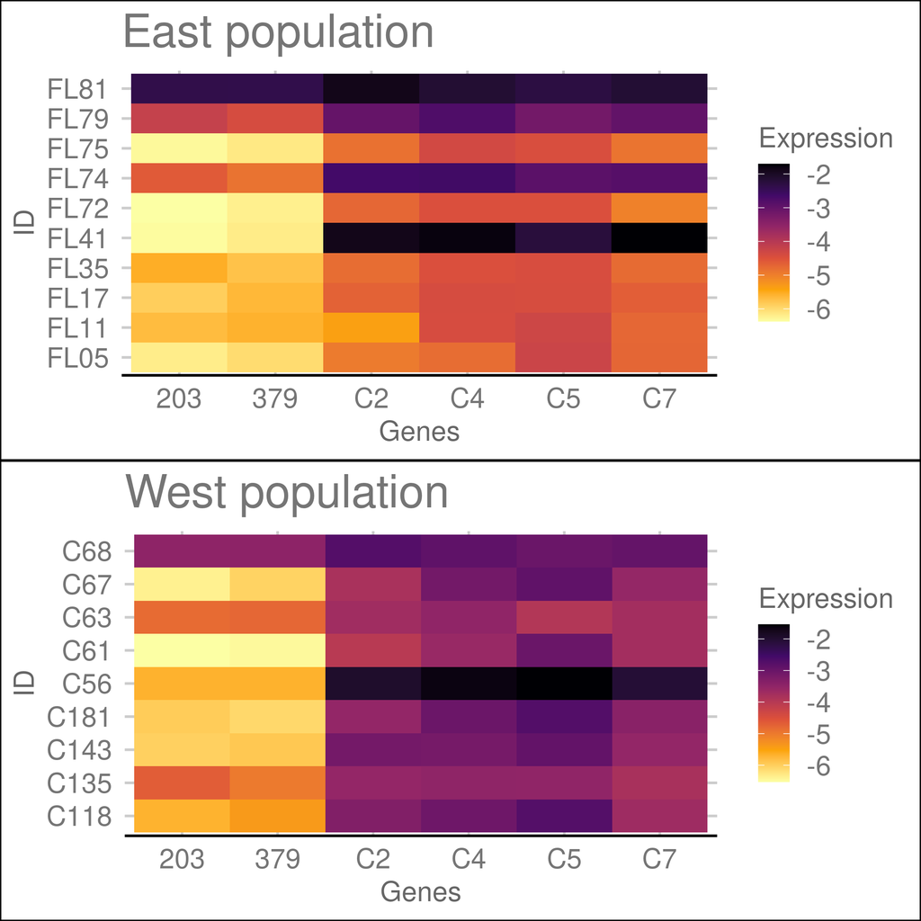

Fig.6-Heat maps of gene expression

## Results : Modelling

Logistic regression to determine significance of gene expression on populations

- All genes show **no significant relation** to the differences between Eastern and Western Monarchs
- **Gene C5** which is the myosin heavy chain gene, shows **comparatively higher association** with populations

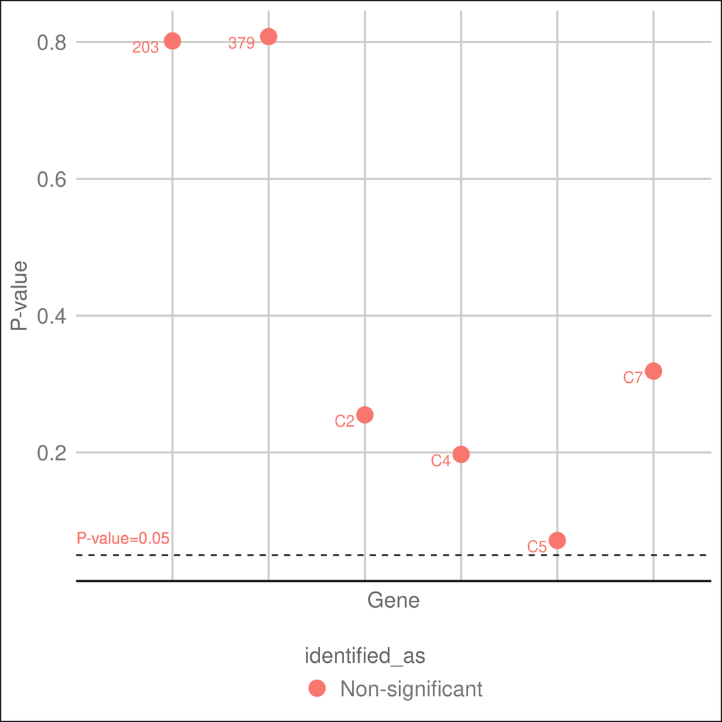

Fig.7-Logistic regression on gene expression

## Discussion

From our analysis we can conclude the following about the Eastern and Western Monarchs:

- There is a significant difference in flight performance between the two populations
- There are no genetic distinction between the two populations

**Thank you :)**